# Alice in the Data Science World

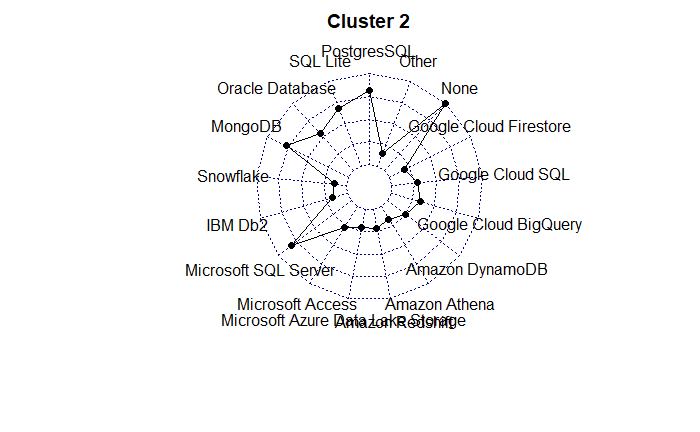

[figure not shown]

- Q31-A: Which of the following business intelligence tools do you use on a regular basis? (Select all that apply)

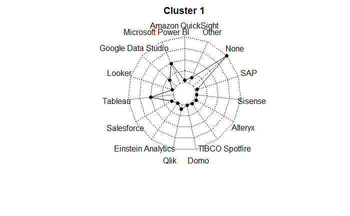

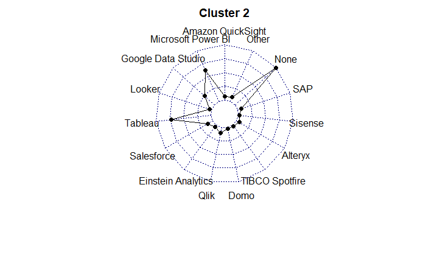

[figure not shown]

- Q36: Where do you publicly share or deploy your data analysis or machine learning applications?

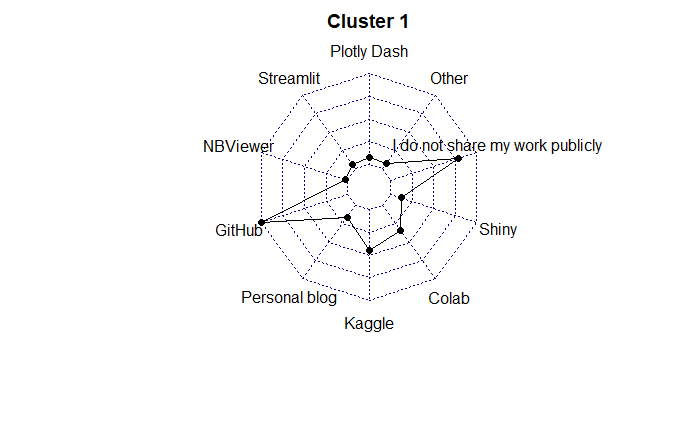

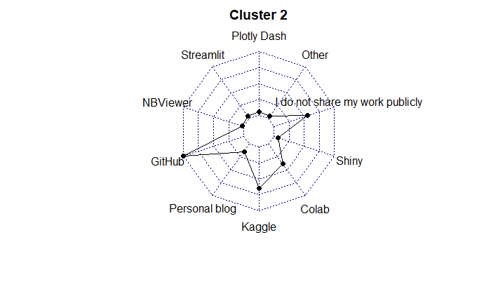

[figure not shown]

## Insights about learning process

- Q37: On which platforms have you begun or completed data science courses?

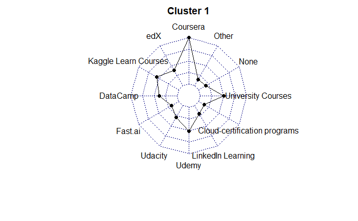

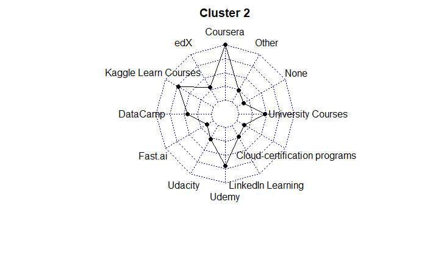

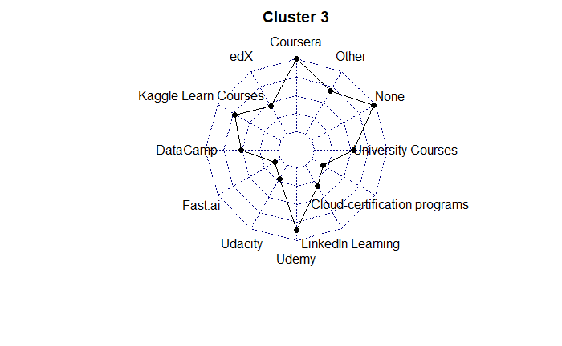

- Q38: What is the primary tool that you use at work or school to analyze data?

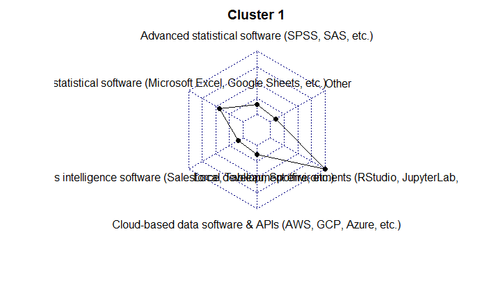

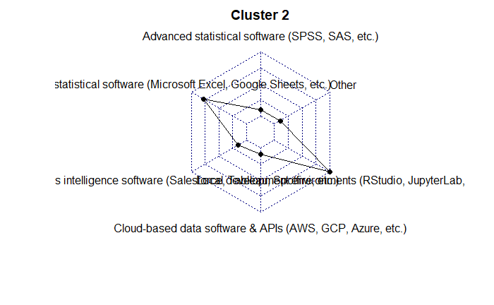

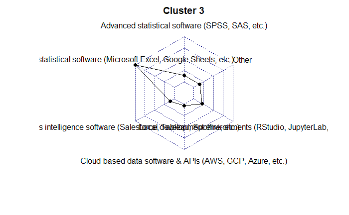

- Q39: Who/what are your favorite media sources that report on data science topics?

[figure not shown]

[figure not shown]

[figure not shown]